# Simulation

abs算法code

```r
## 0) 工具与可重复性
## =====================================================================
options(stringsAsFactors = FALSE)

## =====================================================================
## 内部加速工具（不改变对外 API）
## 说明：
## - 通过一次性构建按行的列累积和 (cumsums) 来将任意区间均值计算从 O(k) 降到 O(1)
## - 所有优化均以隐式属性附着在 Y 上（attr(Y, "._csum")），
##   若缺失则在首次调用时自动构建；对外函数名、参数与用法保持不变
## =====================================================================
.ensure_cumsum <- function(Y) {
  cs <- attr(Y, "._csum")
  if (is.null(cs)) {
    # 构建 n+1 x p 的累计和矩阵：第 1 行是 0，便于用差分快速得到任意区间和
    cs <- rbind(matrix(0, nrow = 1, ncol = ncol(Y)),
                apply(Y, 2, cumsum))
    attr(Y, "._csum") <- cs
  }
  attr(Y, "._csum")
}

.segment_means_fast <- function(cs, t_left, t_mid, t_right) {
  # cs 的行索引与时间点对齐：第 0 个时间点位于行 1
  # 区间 (t_left+1):t_mid 与 (t_mid+1):t_right
  n1 <- t_mid - t_left
  n2 <- t_right - t_mid
  sum1 <- cs[t_mid + 1, , drop = FALSE] - cs[t_left + 1, , drop = FALSE]
  sum2 <- cs[t_right + 1, , drop = FALSE] - cs[t_mid + 1, , drop = FALSE]
  mean1 <- sum1 / n1
  mean2 <- sum2 / n2
  list(mean1 = mean1, mean2 = mean2, n1 = n1, n2 = n2)
}

## =====================================================================
## 1) 代价函数 & 二元分割（保持 API，不改变名称/参数）
## =====================================================================
compute_cost <- function(Y, t_left, t_mid, t_right, p = 2) {
  if ((t_left >= t_mid) || (t_mid >= t_right)) return(0)
  # 尝试使用累计和加速；若不可用则回退到原始实现
  cs <- attr(Y, "._csum")
  if (!is.null(cs)) {
    seg <- .segment_means_fast(cs, t_left, t_mid, t_right)
    n1 <- seg$n1; n2 <- seg$n2; n_total <- t_right - t_left
    diff <- as.numeric(seg$mean2 - seg$mean1)
    weight <- sqrt((n1 * n2) / n_total)
    if (identical(p, "inf")) {
      norm_p <- max(abs(diff))
    } else {
      norm_p <- sum(abs(diff)^p)^(1/p)
    }
    return(weight * norm_p)
  }
  # 回退路径（仅在未预先构建 cumsum 时触发）
  n1 <- t_mid - t_left
  n2 <- t_right - t_mid
  n_total <- t_right - t_left
  mean1 <- colMeans(Y[(t_left + 1):t_mid, , drop = FALSE])
  mean2 <- colMeans(Y[(t_mid + 1):t_right, , drop = FALSE])
  diff  <- mean2 - mean1
  weight <- sqrt((n1 * n2) / n_total)
  if (identical(p, "inf")) {
    norm_p <- max(abs(diff))
  } else {
    norm_p <- sum(abs(diff)^p)^(1/p)
  }
  weight * norm_p
}

binary_segmentation <- function(Y, beta, t0 = 0, t1 = nrow(Y), min_size = 2, p = 2) {
  # 确保累计和已存在（若无则自动构建）
  .ensure_cumsum(Y)
  left_scan  <- t0 + min_size
  right_scan <- t1 - min_size
  if ((t1 - t0 + 1) < 2 * min_size + 1 || left_scan > right_scan) {
    return(integer(0))
  }
  best_gain <- -Inf
  best_t <- NULL
  # 使用累计和的 compute_cost，按扫描区间求最大增益
  for (t in left_scan:right_scan) {
    gain <- compute_cost(Y, t0, t, t1, p)
    if (gain > best_gain) {
      best_gain <- gain; best_t <- t
    }
  }
  if (!is.null(best_t) && (best_gain > beta)) {
    left  <- binary_segmentation(Y, beta, t0, best_t, min_size, p)
    right <- binary_segmentation(Y, beta, best_t, t1, min_size, p)
    return(c(left, best_t, right))
  } else {
    return(integer(0))
  }
}

## =====================================================================
## 2) 稳定路径：手肘 + 平台 (Kneedle + plateau)
##    （内部同样利用累计和以复用加速）
## =====================================================================
find_elbow <- function(x, y) {
  p1 <- c(x[1], y[1]); p2 <- c(x[length(x)], y[length(y)])
  distances <- numeric(length(x))
  dx <- (p2[1] - p1[1]); dy <- (p2[2] - p1[2])
  denom <- sqrt(dx * dx + dy * dy)
  for (i in seq_along(x)) {
    p <- c(x[i], y[i])
    distances[i] <- abs(dy * p[1] - dx * p[2] + p2[1] * p1[2] - p2[2] * p1[1]) / denom
  }
  idx <- which.max(distances)
  list(beta = x[idx], index = idx)
}

find_plateaus <- function(x, y) {
  plateaus <- list()
  start <- 1
  for (i in 2:length(y)) {
    if (y[i] != y[i - 1]) {
      plateaus[[length(plateaus) + 1]] <- list(
        start = start, end = i - 1, value = y[i - 1], length = (i - 1) - start + 1
      )
      start <- i
    }
  }
  plateaus[[length(plateaus) + 1]] <- list(
    start = start, end = length(y), value = y[length(y)], length = length(y) - start + 1
  )
  plateaus
}

adaptive_binary_segmentation <- function(Y,
                                         beta_min = 3, beta_max = 30, beta_points = 70,
                                         min_size = 2, p = 2, elbow_window = 10,
                                         verbose = FALSE) {
  # 预先构建累计和，加速所有后续成本评估
  .ensure_cumsum(Y)
  beta_list <- seq(beta_min, beta_max, length.out = beta_points)
  results <- vector("list", length(beta_list))
  bp_counts <- integer(length(beta_list))

  for (i in seq_along(beta_list)) {
    b <- beta_list[i]
    t_hat <- sort(binary_segmentation(Y, b, min_size = min_size, p = p))
    results[[i]] <- t_hat
    bp_counts[i] <- length(t_hat)
  }

  el <- find_elbow(beta_list, bp_counts)
  elbow_idx <- el$index
  plateaus <- find_plateaus(beta_list, bp_counts)

  left_bound <- max(1, elbow_idx - elbow_window)
  right_bound <- min(length(beta_list), elbow_idx + elbow_window)

  best_plateau <- NULL
  for (pp in plateaus) {
    if ((pp$start <= right_bound) && (pp$end >= left_bound)) {
      if (is.null(best_plateau) || pp$length > best_plateau$length) best_plateau <- pp
    }
  }
  best_beta <- beta_list[round((best_plateau$start + best_plateau$end) / 2)]

  if (isTRUE(verbose)) {
    cat("所有 plateau 区间:\n")
    for (pp in plateaus) {
      cat(sprintf("β = %.2f–%.2f, 长度 = %d, 变点数 = %d\n",
                  beta_list[pp$start], beta_list[pp$end], pp$length, pp$value))
    }
    cat(sprintf("\nElbow 候选 β = %.2f\n", el$beta))
    cat(sprintf("最终推荐 β = %.2f (在 elbow 附近 plateau 最长)\n\n", best_beta))
  }

  list(
    beta_list = beta_list,
    bp_counts = bp_counts,
    results = results,
    plateaus = plateaus,
    elbow_beta = el$beta,
    best_beta = best_beta
  )
}

plot_segmentation_path <- function(res) {
  beta_list <- res$beta_list; bp_counts <- res$bp_counts
  plot(beta_list, bp_counts, type = "b", pch = 19,
       xlab = "Beta", ylab = "Number of Change Points",
       main = "Stability Path: Beta vs. Change Points")
  abline(v = res$elbow_beta, col = "red", lty = 2, lwd = 2)
  abline(v = res$best_beta,  col = "blue", lty = 2, lwd = 2)
  legend("topright", legend = c("Elbow", "Final Beta (Plateau)"),
         col = c("red", "blue"), lty = 2, bty = "n")
}
```

数据导入

```r
# 定义一个函数，读取指定文件夹中的所有 Excel 文件
read_excel_files_in_directory <- function(directory_path) {
  # 获取指定目录下的所有 Excel 文件（以 .xlsx 或 .xls 结尾）
  excel_files <- list.files(directory_path, pattern = "\\.xlsx$|\\.xls$", full.names = TRUE)

  # 创建一个空的列表来存储读取的数据
  data_list <- list()

  # 遍历每个 Excel 文件
  for (file in excel_files) {
    # 读取 Excel 文件的数据
    try({
      df <- read_excel(file)
      data_list[[file]] <- df
      print(paste("成功读取文件:", file))
    }, silent = TRUE)
  }

  # 返回一个包含所有文件数据的列表
  return(data_list)
}

# 指定文件夹路径
directory_path <- "C:/Users/86133/Desktop/software/changepoint/rawdata/per_game"

# 调用函数读取并存储所有 Excel 文件
pergame_list <- read_excel_files_in_directory(directory_path)
```

```
[1] "成功读取文件: C:/Users/86133/Desktop/software/changepoint/rawdata/per_game/2000_pergame.xlsx"
[1] "成功读取文件: C:/Users/86133/Desktop/software/changepoint/rawdata/per_game/2001_pergame.xlsx"
[1] "成功读取文件: C:/Users/86133/Desktop/software/changepoint/rawdata/per_game/2002_pergame.xlsx"
[1] "成功读取文件: C:/Users/86133/Desktop/software/changepoint/rawdata/per_game/2003_pergame.xlsx"
[1] "成功读取文件: C:/Users/86133/Desktop/software/changepoint/rawdata/per_game/2004_pergame.xlsx"
[1] "成功读取文件: C:/Users/86133/Desktop/software/changepoint/rawdata/per_game/2005_pergame.xlsx"
[1] "成功读取文件: C:/Users/86133/Desktop/software/changepoint/rawdata/per_game/2006_pergame.xlsx"
[1] "成功读取文件: C:/Users/86133/Desktop/software/changepoint/rawdata/per_game/2007_pergame.xlsx"
[1] "成功读取文件: C:/Users/86133/Desktop/software/changepoint/rawdata/per_game/2008_pergame.xlsx"
[1] "成功读取文件: C:/Users/86133/Desktop/software/changepoint/rawdata/per_game/2009_pergame.xlsx"
[1] "成功读取文件: C:/Users/86133/Desktop/software/changepoint/rawdata/per_game/2010_pergame.xlsx"
[1] "成功读取文件: C:/Users/86133/Desktop/software/changepoint/rawdata/per_game/2011_pergame.xlsx"
[1] "成功读取文件: C:/Users/86133/Desktop/software/changepoint/rawdata/per_game/2012_pergame.xlsx"
[1] "成功读取文件: C:/Users/86133/Desktop/software/changepoint/rawdata/per_game/2013_pergame.xlsx"
[1] "成功读取文件: C:/Users/86133/Desktop/software/changepoint/rawdata/per_game/2014_pergame.xlsx"
[1] "成功读取文件: C:/Users/86133/Desktop/software/changepoint/rawdata/per_game/2015_pergame.xlsx"
[1] "成功读取文件: C:/Users/86133/Desktop/software/changepoint/rawdata/per_game/2016_pergame.xlsx"
[1] "成功读取文件: C:/Users/86133/Desktop/software/changepoint/rawdata/per_game/2017_pergame.xlsx"
[1] "成功读取文件: C:/Users/86133/Desktop/software/changepoint/rawdata/per_game/2018_pergame.xlsx"
[1] "成功读取文件: C:/Users/86133/Desktop/software/changepoint/rawdata/per_game/2019_pergame.xlsx"
[1] "成功读取文件: C:/Users/86133/Desktop/software/changepoint/rawdata/per_game/2020_pergame.xlsx"
[1] "成功读取文件: C:/Users/86133/Desktop/software/changepoint/rawdata/per_game/2021_pergame.xlsx"
[1] "成功读取文件: C:/Users/86133/Desktop/software/changepoint/rawdata/per_game/2022_pergame.xlsx"
[1] "成功读取文件: C:/Users/86133/Desktop/software/changepoint/rawdata/per_game/2023_pergame.xlsx"
```

```r
# 如果需要将所有文件的数据合并为一个大的数据框
combinedpergame_data <- do.call(rbind, pergame_list)
# 输出合并后的数据框
print(combinedpergame_data)
```

```
# A tibble: 740 × 46
      Rk Team      G    MP    FG   FGA `FG%`  `3P` `3PA` `3P%`  `2P` `2PA` `2P%`
 * <dbl> <chr> <dbl> <dbl> <dbl> <dbl> <dbl> <dbl> <dbl> <dbl> <dbl> <dbl> <dbl>
 1    26 Atla…    82  241.  35.1  81.3 0.431   4.1  11.4 0.357  31    69.9 0.443
 2    16 Bost…    82  242.  33.8  79.1 0.428   7.2  19.9 0.363  26.6  59.2 0.45
 3    24 Char…    82  242.  34.1  79.3 0.431   4.1  12   0.346  30    67.3 0.446
 4    29 Chic…    82  242.  33.2  78.2 0.424   4    11.6 0.346  29.2  66.6 0.438
 5    22 Clev…    82  242.  35.2  79.7 0.442   2.7   8   0.334  32.6  71.6 0.455
 6     4 Dall…    82  242.  37.6  81.9 0.459   6.3  16.5 0.381  31.3  65.4 0.479
 7    11 Denv…    82  241.  36.3  83.9 0.433   6.2  17.6 0.355  30.1  66.3 0.454
 8    13 Detr…    82  242.  35.6  83.9 0.424   4.7  13.6 0.35   30.9  70.3 0.439
 9    21 Gold…    82  241.  35.8  87.5 0.409   3.4  11.8 0.293  32.4  75.7 0.427
10     9 Hous…    82  242.  35.9  79.2 0.453   6.1  17.2 0.357  29.7  62   0.48
# ℹ 730 more rows
# ℹ 33 more variables: FT <dbl>, FTA <dbl>, `FT%` <dbl>, ORB <dbl>, DRB <dbl>,
#   TRB <dbl>, AST <dbl>, STL <dbl>, BLK <dbl>, TOV <dbl>, PF <dbl>, PTS <dbl>,
#   FG1 <dbl>, FGA1 <dbl>, `FG%1` <dbl>, `3P1` <dbl>, `3PA1` <dbl>,
#   `3P%1` <dbl>, `2P1` <dbl>, `2PA1` <dbl>, `2P%1` <dbl>, FT1 <dbl>,
#   FTA1 <dbl>, `FT%1` <dbl>, ORB1 <dbl>, DRB1 <dbl>, TRB1 <dbl>, AST1 <dbl>,
#   STL1 <dbl>, BLK1 <dbl>, TOV1 <dbl>, PF1 <dbl>, PTS1 <dbl>
```

```r
combinedpergame_data <- do.call(rbind, pergame_list)
subpergame <- pergame_list[[1]][,2:ncol(pergame_list[[1]])]
pergame_mean <- data.frame(matrix(NA, nrow = 0, ncol = ncol(subpergame)))
colnames(pergame_mean) <- colnames(subpergame)
colnames(pergame_mean)[1] <- "year"
pergame_var <- pergame_mean
for (i in 1:length(pergame_list)) {
  subpergame <- pergame_list[[i]][,2:ncol(pergame_list[[i]])]
  pergame_mean[i,] <- sapply(subpergame, function(x) if (is.numeric(x)) mean(x, na.rm = TRUE) else NA)
  pergame_var[i,] <- sapply(subpergame, function(x) if (is.numeric(x)) var(x, na.rm = TRUE) else NA)
  pergame_mean[i,1] <- i+1999
  pergame_var[i,1] <- i+1999
}
```

原始数据转化为张量tensor_nba:

```r
# 定义一个函数，读取指定文件夹中的所有 Excel 文件
read_excel_files_in_directory <- function(directory_path) {
  # 获取指定目录下的所有 Excel 文件（以 .xlsx 或 .xls 结尾）
  excel_files <- list.files(directory_path, pattern = "\\.xlsx$|\\.xls$", full.names = TRUE)

  # 创建一个空的列表来存储读取的数据
  data_list <- list()

  # 遍历每个 Excel 文件
  for (file in excel_files) {
    # 读取 Excel 文件的数据
    try({
      df <- read_excel(file)
      data_list[[file]] <- df
      print(paste("成功读取文件:", file))
    }, silent = TRUE)
  }

  # 返回一个包含所有文件数据的列表
  return(data_list)
}

# 指定文件夹路径
directory_path <- "C:/Users/86133/Desktop/software/changepoint/rawdata/per_game_rename_complete"

# 调用函数读取并存储所有 Excel 文件
pergame_list_re <- read_excel_files_in_directory(directory_path)
```

```
[1] "成功读取文件: C:/Users/86133/Desktop/software/changepoint/rawdata/per_game_rename_complete/2000_pergame.xlsx"
[1] "成功读取文件: C:/Users/86133/Desktop/software/changepoint/rawdata/per_game_rename_complete/2001_pergame.xlsx"
[1] "成功读取文件: C:/Users/86133/Desktop/software/changepoint/rawdata/per_game_rename_complete/2002_pergame.xlsx"
[1] "成功读取文件: C:/Users/86133/Desktop/software/changepoint/rawdata/per_game_rename_complete/2003_pergame.xlsx"
[1] "成功读取文件: C:/Users/86133/Desktop/software/changepoint/rawdata/per_game_rename_complete/2004_pergame.xlsx"
[1] "成功读取文件: C:/Users/86133/Desktop/software/changepoint/rawdata/per_game_rename_complete/2005_pergame.xlsx"
[1] "成功读取文件: C:/Users/86133/Desktop/software/changepoint/rawdata/per_game_rename_complete/2006_pergame.xlsx"
[1] "成功读取文件: C:/Users/86133/Desktop/software/changepoint/rawdata/per_game_rename_complete/2007_pergame.xlsx"
[1] "成功读取文件: C:/Users/86133/Desktop/software/changepoint/rawdata/per_game_rename_complete/2008_pergame.xlsx"
[1] "成功读取文件: C:/Users/86133/Desktop/software/changepoint/rawdata/per_game_rename_complete/2009_pergame.xlsx"
[1] "成功读取文件: C:/Users/86133/Desktop/software/changepoint/rawdata/per_game_rename_complete/2010_pergame.xlsx"
[1] "成功读取文件: C:/Users/86133/Desktop/software/changepoint/rawdata/per_game_rename_complete/2011_pergame.xlsx"
[1] "成功读取文件: C:/Users/86133/Desktop/software/changepoint/rawdata/per_game_rename_complete/2012_pergame.xlsx"
[1] "成功读取文件: C:/Users/86133/Desktop/software/changepoint/rawdata/per_game_rename_complete/2013_pergame.xlsx"
[1] "成功读取文件: C:/Users/86133/Desktop/software/changepoint/rawdata/per_game_rename_complete/2014_pergame.xlsx"
[1] "成功读取文件: C:/Users/86133/Desktop/software/changepoint/rawdata/per_game_rename_complete/2015_pergame.xlsx"
[1] "成功读取文件: C:/Users/86133/Desktop/software/changepoint/rawdata/per_game_rename_complete/2016_pergame.xlsx"
[1] "成功读取文件: C:/Users/86133/Desktop/software/changepoint/rawdata/per_game_rename_complete/2017_pergame.xlsx"
[1] "成功读取文件: C:/Users/86133/Desktop/software/changepoint/rawdata/per_game_rename_complete/2018_pergame.xlsx"
[1] "成功读取文件: C:/Users/86133/Desktop/software/changepoint/rawdata/per_game_rename_complete/2019_pergame.xlsx"
[1] "成功读取文件: C:/Users/86133/Desktop/software/changepoint/rawdata/per_game_rename_complete/2020_pergame.xlsx"
[1] "成功读取文件: C:/Users/86133/Desktop/software/changepoint/rawdata/per_game_rename_complete/2021_pergame.xlsx"
[1] "成功读取文件: C:/Users/86133/Desktop/software/changepoint/rawdata/per_game_rename_complete/2022_pergame.xlsx"
[1] "成功读取文件: C:/Users/86133/Desktop/software/changepoint/rawdata/per_game_rename_complete/2023_pergame.xlsx"
```

```r
# 如果需要将所有文件的数据合并为一个大的数据框
combinedpergame_data_re <- do.call(rbind, pergame_list_re)
# 输出合并后的数据框
print(combinedpergame_data_re)
```

```
# A tibble: 720 × 46
      Rk Team      G    MP    FG   FGA `FG%`  `3P` `3PA` `3P%`  `2P` `2PA` `2P%`
 * <dbl> <chr> <dbl> <dbl> <dbl> <dbl> <dbl> <dbl> <dbl> <dbl> <dbl> <dbl> <dbl>
 1    26 Atla…    82  241.  35.1  81.3 0.431   4.1  11.4 0.357  31    69.9 0.443
 2    16 Bost…    82  242.  33.8  79.1 0.428   7.2  19.9 0.363  26.6  59.2 0.45
 3    23 Broo…    82  241.  33.9  79.9 0.425   4.4  13.2 0.333  29.5  66.7 0.443
 4     0 Char…    82  242   35.7  80.6 0.443   4.8  13.7 0.354  30.8  66.9 0.461
 5    29 Chic…    82  242.  33.2  78.2 0.424   4    11.6 0.346  29.2  66.6 0.438
 6    22 Clev…    82  242.  35.2  79.7 0.442   2.7   8   0.334  32.6  71.6 0.455
 7     4 Dall…    82  242.  37.6  81.9 0.459   6.3  16.5 0.381  31.3  65.4 0.479
 8    11 Denv…    82  241.  36.3  83.9 0.433   6.2  17.6 0.355  30.1  66.3 0.454
 9    13 Detr…    82  242.  35.6  83.9 0.424   4.7  13.6 0.35   30.9  70.3 0.439
10    21 Gold…    82  241.  35.8  87.5 0.409   3.4  11.8 0.293  32.4  75.7 0.427
# ℹ 710 more rows
# ℹ 33 more variables: FT <dbl>, FTA <dbl>, `FT%` <dbl>, ORB <dbl>, DRB <dbl>,
#   TRB <dbl>, AST <dbl>, STL <dbl>, BLK <dbl>, TOV <dbl>, PF <dbl>, PTS <dbl>,
#   FG1 <dbl>, FGA1 <dbl>, `FG%1` <dbl>, `3P1` <dbl>, `3PA1` <dbl>,
#   `3P%1` <dbl>, `2P1` <dbl>, `2PA1` <dbl>, `2P%1` <dbl>, FT1 <dbl>,
#   FTA1 <dbl>, `FT%1` <dbl>, ORB1 <dbl>, DRB1 <dbl>, TRB1 <dbl>, AST1 <dbl>,
#   STL1 <dbl>, BLK1 <dbl>, TOV1 <dbl>, PF1 <dbl>, PTS1 <dbl>
```

```r
#转为tensor
# 假设 pergame_list 是按年份顺序排列的列表（2000-2023），每个元素为 p×q 矩阵

# 1. 检查所有矩阵维度是否一致
p <- nrow(pergame_list_re[[1]])
q <- ncol(pergame_list_re[[1]])
n_years <- length(pergame_list_re)
#检查每层的行列数是否一致
for (i in seq_along(pergame_list_re)) {
  if (nrow(pergame_list_re[[i]]) != p || ncol(pergame_list_re[[i]]) != q) {
    stop("矩阵维度不一致，无法构建张量")
  }
}

# 2. 直接合并为行×列×层的三维数组（维度顺序: p×q×n_years）
tensor <- array(
  data = unlist(pergame_list_re),
  dim = c(p, q, n_years)  # 行 × 列 × 层（年份）
)
tensor <- tensor[, -1, ]
column_names <- as.character(tensor[, 1, 1])
tensor <- tensor[, -2:-1, ] #删掉第一列(球队和G)

tensor_numeric <- array(as.numeric(tensor), dim = dim(tensor)) #转为数值型

# 验证维度
cat("张量维度 (行 × 列 × 层):", dim(tensor))
```

```
张量维度 (行 × 列 × 层): 30 43 24
```

```r
library(rTensor)
tensor_nba <- as.tensor(tensor_numeric)
attr(tensor, "column_names") <- column_names  #取第一层第一列作为列名
```

# proposed method

### Binary Segmentation

Given a multivariate time series $Y_1, Y_2, \dots, Y_n \in \mathbb{R}^d$. For any candidate change point $t \in (t_{k-1}, t_{k+1})$, we define the cost function as:

$$c(y_{t_{k-1}..t_{k+1}}) = \sqrt{\frac{(t_k - t_{k-1})(t_{k+1} - t_k)}{t_{k+1} - t_{k-1}}} \cdot \left\| \bar{Y}_{(t_k, t_{k+1}]} - \bar{Y}_{(t_{k-1}, t_k]} \right\|_p$$

where $\bar{Y}_{(a, b]}$ is the mean of the data in the interval $(a, b]$, and $\|\cdot\|_p$ is the $\ell_p$-norm.

Binary Segmentation: In the current interval $[t_0, t_1]$, enumerate all possible split points $t \in \{\,t_0 + minsize, \dots, t_1 - minsize\,\}$, compute the cost $c(t)$ for each split, and select the maximum cost $c^*$ with optimal point $t^*$. If $c^* > \beta$, accept $t^*$ as a change point, and recursively apply the same procedure to $[t_0, t^*]$ and $[t^*, t_1]$; If $c^* \leq \beta$, do not split further.

#### β网格搜索

输入：

- 数据矩阵 $Y_{1:n}$ ,即Y
- 子区间 $[t_0, t_1)$
- 区间最小段长 `min_size`
- 惩罚项强度 $β$
- 范数类型 $\ell_p$ ,即p

**伪代码：**

```
Input
  Data matrix $Y_{1:n}$,
  Interval $[t_0, t_1)$,
  Minimum segment length $\mathtt{min\_size}$,
  Penalty parameter $\beta$,
  Norm type $\ell_p$

Function BinarySegmentation(Y, t0 = 0, t1 = n, β, min_size, p):

Initialize:
    best_gain ← -∞
    best_t ← NULL

For t in (t0 + min_size) to (t1 - min_size):
    Compute gain = c(Y[t0+1 : t1], split at t)
    If gain > best_gain:
        best_gain ← gain
        best_t ← t

If best_gain > β:
    # Accept split
    left_changes ← BinarySegmentation(Y, t0, best_t, β, min_size, p)
    right_changes ← BinarySegmentation(Y, best_t, t1, β, min_size, p)
    return left_changes ∪ {best_t} ∪ right_changes
Else:
    return ∅
```

Binary Segmentation code:

Run the algorithm with a sequence of β values and observe how the number of change points changes.

```r
set.seed(22)
cp_decomp <- parafac(tensor_numeric, nfac = 2, const=c("nonneg","nonneg","nonneg"), verbose = FALSE)
# cp_decomp
# const()
# 提取结果
A <- cp_decomp$A  # 第一模态因子矩阵
B <- cp_decomp$B  # 第二模态因子矩阵
C <- cp_decomp$C  # 时间模态因子矩阵

Y <- C
# Y
# ------------------------
# 定义 cost 函数
# ------------------------

compute_cost <- function(Y, t_left, t_mid, t_right, p=2 ) {
   #p = 2范数类型
  if ((t_left >= t_mid) || (t_mid >= t_right)) return(0)

  n1 <- t_mid - t_left
  n2 <- t_right - t_mid
  n_total <- t_right - t_left

  mean1 <- colMeans(Y[(t_left + 1):t_mid, , drop = FALSE])
  mean2 <- colMeans(Y[(t_mid + 1):t_right, , drop = FALSE])

  diff <- mean2 - mean1
  weight <- sqrt((n1 * n2) / n_total)

  # 用 sum(abs(diff)^p)^(1/p) 计算 p 范数
    if (p == "inf") {
    norm_p <- max(abs(diff))
  } else {
    norm_p <- sum(abs(diff)^p)^(1/p)
  }


  cost <- weight * norm_p
  return(cost)
}


# ------------------------
# 二元分割函数（递归）
# ------------------------
binary_segmentation <- function(Y, beta, t0 = 0, t1 = nrow(Y), min_size=2, p=2) {
  # 先算扫描边界
  left_scan  <- t0 + min_size
  right_scan <- t1 - min_size

  # 如果无可扫范围，直接返回
  if ((t1 - t0 + 1) < 2*min_size + 1 || left_scan > right_scan) {
    return(integer(0))
  }

  best_gain <- -Inf
  best_t <- NULL

  for (t in left_scan:right_scan) {
    gain <- compute_cost(Y, t0, t, t1, p)
    if (gain > best_gain) {
      best_gain <- gain
      best_t <- t
    }
  }

  if (!is.null(best_t) && (best_gain > beta)) {
    left <- binary_segmentation(Y, beta, t0, best_t, min_size, p)
    right <- binary_segmentation(Y, beta, best_t, t1, min_size, p)
    return(c(left, best_t, right))
  } else {
    return(integer(0))
  }
}
```

下面结果是遍历beta的nba数据变点结果:

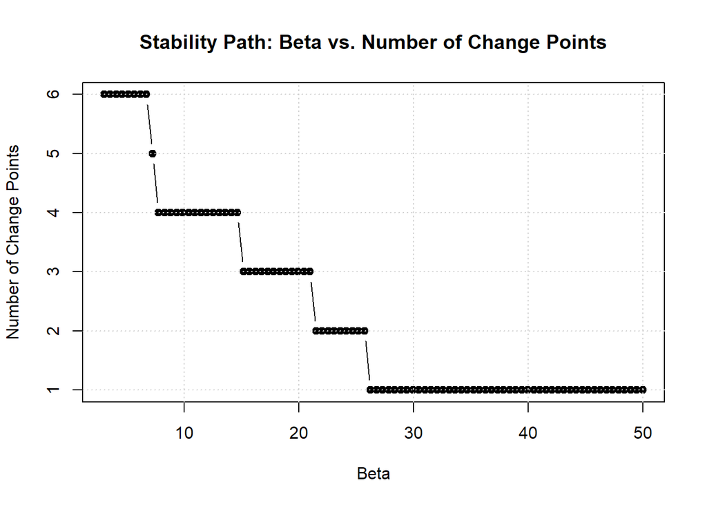

```r
# ------------------------
# 遍历多个 β 值
# ------------------------
beta_list <- seq(3, 50, length.out = 90)
results <- list()
bp_counts <- numeric(length(beta_list))
#beta_list: 遍历的 β 值序列，例如 seq(3, 30, length.out = 70), bp_counts: 对应每个 β 下检测到的变点数量（整型向量）

for (i in seq_along(beta_list)) {
  beta <- beta_list[i]
  t_hat <- sort(binary_segmentation(Y, beta))
  results[[i]] <- t_hat
  bp_counts[i] <- length(t_hat)
}

# ------------------------
# 绘图：β vs 变点数
# ------------------------
plot(beta_list, bp_counts, type = "b", pch = 19,
     xlab = "Beta", ylab = "Number of Change Points",
     main = "Stability Path: Beta vs. Number of Change Points")
grid()
```

```r
# 输出变点结构供进一步分析
for (i in seq_along(beta_list)) {
  cat(sprintf("β = %.2f: changepoints = %s\n", beta_list[i], paste(results[[i]], collapse = ", ")))
}
```

```
β = 3.00: changepoints = 4, 7, 13, 16, 18, 20
β = 3.53: changepoints = 4, 7, 13, 16, 18, 20
β = 4.06: changepoints = 4, 7, 13, 16, 18, 20
β = 4.58: changepoints = 4, 7, 13, 16, 18, 20
β = 5.11: changepoints = 4, 7, 13, 16, 18, 20
β = 5.64: changepoints = 4, 7, 13, 16, 18, 20
β = 6.17: changepoints = 4, 7, 13, 16, 18, 20
β = 6.70: changepoints = 4, 7, 13, 16, 18, 20
β = 7.22: changepoints = 4, 7, 13, 16, 18
β = 7.75: changepoints = 7, 13, 16, 18
β = 8.28: changepoints = 7, 13, 16, 18
β = 8.81: changepoints = 7, 13, 16, 18
β = 9.34: changepoints = 7, 13, 16, 18
β = 9.87: changepoints = 7, 13, 16, 18
β = 10.39: changepoints = 7, 13, 16, 18
β = 10.92: changepoints = 7, 13, 16, 18
β = 11.45: changepoints = 7, 13, 16, 18
β = 11.98: changepoints = 7, 13, 16, 18
β = 12.51: changepoints = 7, 13, 16, 18
β = 13.03: changepoints = 7, 13, 16, 18
β = 13.56: changepoints = 7, 13, 16, 18
β = 14.09: changepoints = 7, 13, 16, 18
β = 14.62: changepoints = 7, 13, 16, 18
β = 15.15: changepoints = 7, 16, 18
β = 15.67: changepoints = 7, 16, 18
β = 16.20: changepoints = 7, 16, 18
β = 16.73: changepoints = 7, 16, 18
β = 17.26: changepoints = 7, 16, 18
β = 17.79: changepoints = 7, 16, 18
β = 18.31: changepoints = 7, 16, 18
β = 18.84: changepoints = 7, 16, 18
β = 19.37: changepoints = 7, 16, 18
β = 19.90: changepoints = 7, 16, 18
β = 20.43: changepoints = 7, 16, 18
β = 20.96: changepoints = 7, 16, 18
β = 21.48: changepoints = 7, 16
β = 22.01: changepoints = 7, 16
β = 22.54: changepoints = 7, 16
β = 23.07: changepoints = 7, 16
β = 23.60: changepoints = 7, 16
```

[output cut: 35 more lines]

```
β = 42.61: changepoints = 16
β = 43.13: changepoints = 16
β = 43.66: changepoints = 16
β = 44.19: changepoints = 16
β = 44.72: changepoints = 16
β = 45.25: changepoints = 16
β = 45.78: changepoints = 16
β = 46.30: changepoints = 16
β = 46.83: changepoints = 16
β = 47.36: changepoints = 16
β = 47.89: changepoints = 16
β = 48.42: changepoints = 16
β = 48.94: changepoints = 16
β = 49.47: changepoints = 16
β = 50.00: changepoints = 16
```

- β 怎么确定？
  1. **先用手肘法** 找到拐点 β（候选）：取第一点和最后一点把它们连成一条直线，对曲线上每个点计算它到直线的**垂直距离**，距离最大的那一点，就是和端点连线“偏得最远”的点，当作“肘部”
  2. **在 elbow 附近（窗口内）搜索**：找到一个区间里变点数稳定的“最长 plateau”（变点数相同的连续 β 区间），取该 plateau 的中点 β 作为最终beta
  3. 先在**手肘附近窗口**里找**最长 plateau**；

     若窗口里**找不到**（极端/锯齿曲线）：则取**全局最长 plateau**；

     若**根本没有 plateau**：直接用 **`elbow_beta`**

code:

**输出效果**

1. 红线：手肘法选出的候选

   蓝线：在 elbow 附近 plateau 区间里挑出的推荐

[figure not shown]

```r
#先运行遍历beta,得到beta_list: 遍历的 β 值序列，例如 seq(3, 30, length.out = 70)和bp_counts: 对应每个 β 下检测到的变点数量（整型向量）

# ------------------------
# 手肘法 (Kneedle)
# ------------------------
find_elbow <- function(x, y) {
  p1 <- c(x[1], y[1])
  p2 <- c(x[length(x)], y[length(y)])

  distances <- numeric(length(x))
  for (i in seq_along(x)) {
    p <- c(x[i], y[i])
    distances[i] <- abs((p2[2] - p1[2]) * p[1] -
                        (p2[1] - p1[1]) * p[2] +
                        p2[1] * p1[2] - p2[2] * p1[1]) /
                    sqrt((p2[2] - p1[2])^2 + (p2[1] - p1[1])^2)
  }
  idx <- which.max(distances)
  return(list(beta = x[idx], index = idx))
}

# ------------------------
# 找 plateau 区间
# ------------------------
find_plateaus <- function(x, y) {
  plateaus <- list()
  start <- 1
  for (i in 2:length(y)) {
    if (y[i] != y[i-1]) {
      plateaus[[length(plateaus)+1]] <- list(
        start = start,
        end = i-1,
        value = y[i-1],
        length = (i-1) - start + 1
      )
      start <- i
    }
  }
  # 最后一个 plateau
  plateaus[[length(plateaus)+1]] <- list(
    start = start,
    end = length(y),
    value = y[length(y)],
    length = length(y) - start + 1
  )
  return(plateaus)
}

# ------------------------
# 主逻辑
# ------------------------
plateaus <- find_plateaus(beta_list, bp_counts)

# 1. 手肘法
elbow <- find_elbow(beta_list, bp_counts)
elbow_beta <- elbow$beta
elbow_idx <- elbow$index

# 2. 在 elbow 附近找最长 plateau
window <- 10
best_plateau <- NULL
for (p in plateaus) {
  if ((p$start <= elbow_idx + window) && (p$end >= elbow_idx - window)) {
    if (is.null(best_plateau) || p$length > best_plateau$length) {
      best_plateau <- p
    }
  }
}

best_beta <- beta_list[round((best_plateau$start + best_plateau$end)/2)]

# ------------------------
# 可视化
# ------------------------
plot(beta_list, bp_counts, type = "b", pch = 19,
     xlab = "Beta", ylab = "Number of Change Points",
     main = "Stability Path: Beta vs. Change Points")
abline(v = elbow_beta, col = "red", lty = 2, lwd=2)
abline(v = best_beta, col = "blue", lty = 2, lwd=2)
legend("topright", legend=c("Elbow", "Final Beta (Plateau)"),
       col=c("red", "blue"), lty=2, bty="n")
```

```r
# ------------------------
# 打印结果
# ------------------------
cat("所有 plateau 区间:\n")
```

```
所有 plateau 区间:
```

```r
for (p in plateaus) {
  cat(sprintf("β = %.2f–%.2f, 长度 = %d, 变点数 = %d\n",
              beta_list[p$start], beta_list[p$end],
              p$length, p$value))
}
```

[output not shown]

```r
cat(sprintf("\nElbow 候选 β = %.2f\n", elbow_beta))
```

[output not shown]

```r
cat(sprintf("最终推荐 β = %.2f (在 elbow 附近 plateau 最长)\n", best_beta))
```

[output not shown]

- 二元分割+上述beta选择方法结合：

## （ABS）adaptive_binary_segmentation

**主函数：**

**二元分割函数**（自使用确定beta）**adaptive_binary_segmentation** <- function(Y, beta_min = 3, beta_max = 30, beta_points = 70, min_size=2, p=2, elbow_window=10)

beta_min beta_max beta_points 遍历beta的区间和数量，min_size:变点最小间隔，p:范数，elbow_window:手肘法附近窗口大小

**可视化**：plot_segmentation_path

**应用：**

假设数据矩阵 Y 已经准备好

res <- adaptive_binary_segmentation(Y)

画图

plot_segmentation_path(res)